# Trading BTC based on indicator ensembles

Mark Ziemann

2022-08-05

## Intro

In this report I will be looking at whether a combination of MA derived indicators and RSI works better than each on their own. The theory is that there is a chance that combining them will reduce false positives.

The indicators I will be using are:

1. Simple moving average (SMA)
2. Exponential moving average (EMA)
3. SMA crosses
4. EMA crosses
5. Directional momentum index
6. Stochastic
7. True strength index
8. Double RSI

```r
suppressPackageStartupMessages({
  library("jsonlite")
  library("tidyverse")
  library("runner")
  library("quantmod")
  library("TTR")
  library("vioplot")
  library("parallel")
  library("kableExtra")
})

knitr::opts_chunk$set(fig.width=8, fig.height=8)
```

## Get histotrical price data

Obtaining daily data from CMC.

```r
mydate <- Sys.Date()-1

URL=paste("https://web-api.coinmarketcap.com/v1/cryptocurrency/ohlcv/historical?symbol=BTC&convert=USD&interval=daily&time_start=2013-06-01&time_end=",mydate,sep="")

download.file(URL,destfile="btcdat.txt")

dat <- fromJSON("btcdat.txt")
price <- dat$data$quotes
price <- data.frame(price$time_close, price$quote$USD$high, price$quote$USD$low, price$quote$USD$close,
  price$quote$USD$volume, stringsAsFactors=FALSE)
colnames(price) <- c("date","high","low","close","volume")
price$date <- as.Date(sapply(strsplit(as.character(price$date),"T"),"[[",1))

price2 <- price
```

## Fetch optimised parameters

These have been optimised with backtesting.

```r
params <- read.table("https://mdz-analytics.com/altcoins/BTC/BTC_dat.txt", header=TRUE)

params %>% kbl(caption="optimised backtested parameters") %>%  kable_paper("hover", full_width = F)
```

optimised backtested parameters

| indicator | parameter | meanROI | totalROI | ntrades | ndays | xhodl |
| --- | --- | --- | --- | --- | --- | --- |
| SMA | 44 | 1.163238 | 1586.4227 | 82 | 3351 | 8.619205 |
| EMA | 76 | 1.230865 | 871.0932 | 57 | 3351 | 4.732743 |
| SMAcross | 44,8 | 1.389369 | 1877.8385 | 37 | 3351 | 10.202499 |
| EMAcross | 48,18 | 1.792426 | 1780.3809 | 20 | 3351 | 9.673001 |
| DMI | 8 | 1.108325 | 1985.7852 | 135 | 3351 | 10.788985 |
| TSI | 106,14,4 | 1.129587 | 2227.2895 | 106 | 3351 | 12.101104 |
| stoch | 18,75,3 | 1.095079 | 1660.8402 | 115 | 3351 | 9.023523 |
| RSI2 | 57,95 | 1.144590 | 1491.3590 | 98 | 3351 | 8.102714 |

## Calculate hodl returns

This is the benchmark we use for judging the performance of an indicator. Any strategy with total returns under this value is considered bad.

```r
myend <- price[c(1,nrow(price)),2][2]
mystart <- price[c(1,nrow(price)),2][1]
hodl <- (myend - mystart) / mystart
hodl
```

```
## [1] 178.2737
```

### SMA analysis

Fetching the optimal SMA value and comparing it to price action.

```r
best_sma = as.numeric(params[which(params$indicator == "SMA"),"parameter"])
ma <- SMA(Cl(price),n=best_sma)
price2$SMA <- price$close > ma
```

### SMA cross analysis

Fetching the optimal SMA cross values.

```r
best_sma_cross = params[which(params$indicator == "SMAcross"),"parameter"]
best_sma_cross1 <- as.numeric(unlist(strsplit(best_sma_cross,","))[1])
best_sma_cross2 <- as.numeric(unlist(strsplit(best_sma_cross,","))[2])
sma1 <- SMA(Cl(price),n=best_sma_cross1)
sma2 <- SMA(Cl(price),n=best_sma_cross2)
price2$SMAcross <- sma2>sma1
```

### EMA analysis

Fetching the optimal EMA value and comparing it to price action.

```r
best_ema = as.numeric(params[which(params$indicator == "EMA"),"parameter"])
ema <- EMA(Cl(price),n=best_ema)
price2$EMA <- price$close > ema
```

### EMA cross analysis

Fetching the optimal EMA cross values.

```r
best_ema_cross = params[which(params$indicator == "EMAcross"),"parameter"]
best_ema_cross1 <- as.numeric(unlist(strsplit(best_ema_cross,","))[1])
best_ema_cross2 <- as.numeric(unlist(strsplit(best_ema_cross,","))[2])
ema1 <- EMA(Cl(price),n=best_ema_cross1)
ema2 <- EMA(Cl(price),n=best_ema_cross2)
price2$EMAcross <- ema2>ema1
```

## DMI indicator

Directional movement indicator is a good approach to identify trend changes.

```r
n <- as.numeric(params[params$indicator == "DMI",2])
dmi.adx <- ADX(price[,c("high","low","close")],n=n)
price2$DMI <- dmi.adx[,"DIp"]>dmi.adx[,"DIn"]
```

### TSI indicator

True strength index.

```r
n <- as.numeric(unlist(strsplit(params[params$indicator == "TSI",2],",")))
n1 <- n[1]
n2 <- n[2]
ns <- n[3]

TSI <- function(x, n.first = 25, n.second = 13, n.signal = 7) {
  #True Strength Indicator
  #https://school.stockcharts.com/doku.php?id=technical_indicators:true_strength_index
  x <- try.xts(x, error = as.matrix)
  pc <- x - lag.xts(x, na.pad = T) #force lag.xts to get na padding
  dspc <- EMA(EMA(pc, n = n.first), n = n.second)
  dsapc <- EMA(EMA(abs(pc), n = n.first), n = n.second)

  tsi <- 100 * (dspc/dsapc)
  signal <- EMA(tsi, n = n.signal)
  r <- cbind(tsi, signal)
  r <- reclass(r, x)
  if (!is.null(dim(r))) colnames(r) <- c("tsi", "signal")
  return(r)
}

tsi <- TSI(price$close , n.first = n1, n.second = n2, n.signal = ns )
colnames(tsi) <- c("tsi","sig")
price2$TSI <- tsi[,1]>tsi[,2]
```

### Stochastic

Stochastic oscillator.

```r
n <- as.numeric(unlist(strsplit(params[params$indicator == "stoch",2],",")))
n1 <- n[1]
n2 <- n[2]
n3 <- n[3]

sto <- stoch(HLC(price), nFastK=n1 , nFastD=n2 , nSlowD=n2 ,
  bounded = TRUE, smooth=n3)
price2$stoch <- sto[,"fastK"] > sto[,"fastD"]
```

### Double RSI

Two RSI lines.

```r
n <- as.numeric(unlist(strsplit(params[params$indicator == "RSI2",2],",")))
n1 <- n[1]
n2 <- n[2]

rsi1 <- RSI(price$close,n=n1,maType=EMA)
rsi2 <- RSI(price$close,n=n2,maType=EMA)

price2$RSI2 <- rsi1 > rsi2
```

## Ensemble trading

Now that the indicators have each been calculated, we can open a trade when X indicators are positive and sell when only Y are positive.

In order to decide on X and Y, we should look at the data first.

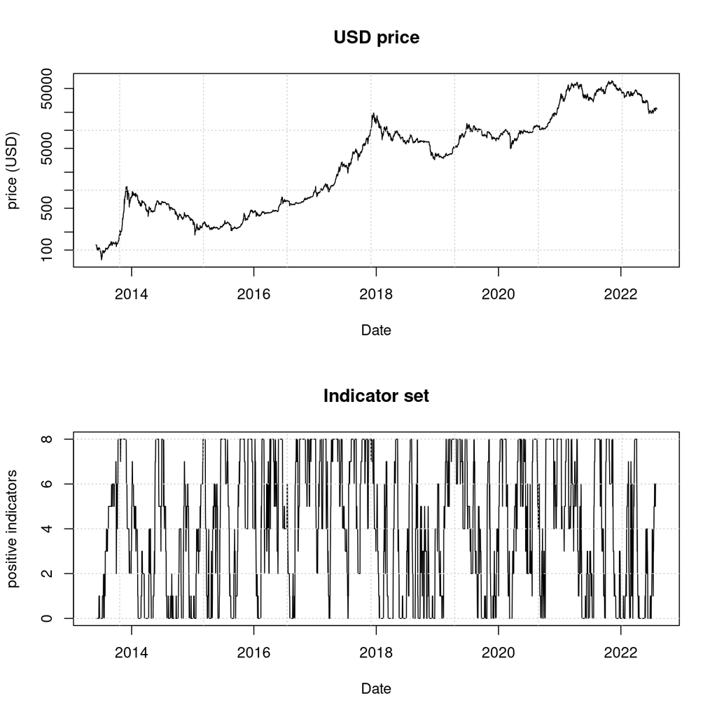

```r
price2[is.na(price2)] <- 0
price2$sum <- rowSums(price2[,6:ncol(price2)])

par(mfrow=c(2,1))
plot(price2$close ~ as.Date(price2$date),type="l",log="y",
  xlab="Date",ylab="price (USD)",main="USD price")
grid()

plot(price2$sum ~ as.Date(price2$date),type="l",
  xlab="Date",ylab="positive indicators",main="Indicator set")
grid()
```

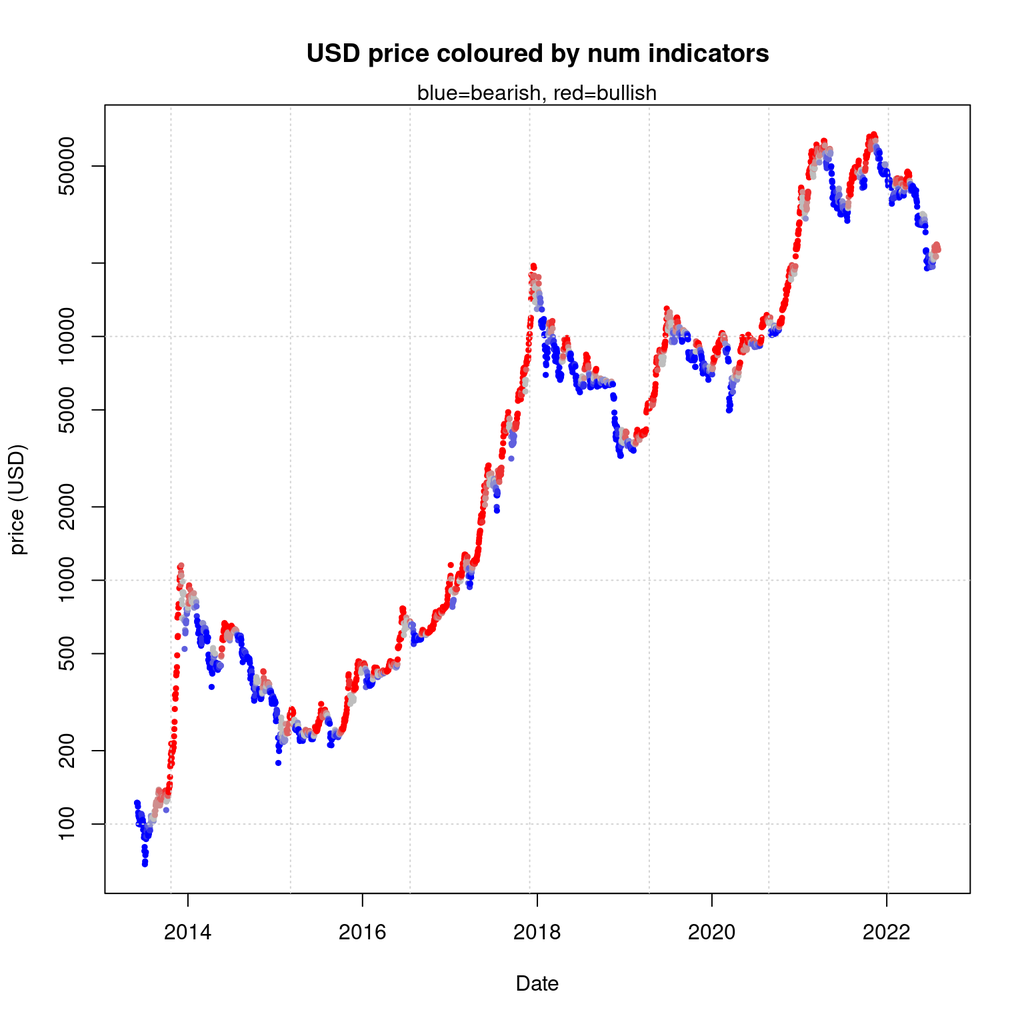

```r
par(mfrow=c(1,1))

colfunc <- colorRampPalette(c("blue", "gray", "red"))(n=max(price2$sum+1))

plot(price2$close ~ as.Date(price2$date),type="p",log="y", pch=19,cex=0.5,
  col=colfunc[price2$sum+1],
  xlab="Date",ylab="price (USD)",
  main="USD price coloured by num indicators")
  mtext("blue=bearish, red=bullish",)
grid()
```

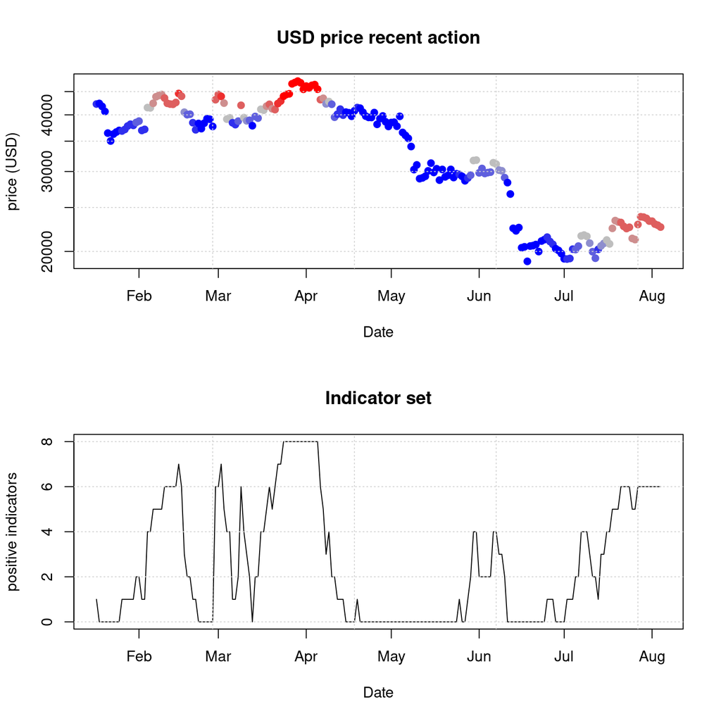

```r
price3 <- tail(price2,200)

par(mfrow=c(2,1))
plot(price3$close ~ as.Date(price3$date),type="p",log="y",
    col=colfunc[price3$sum+1], pch=19,
  xlab="Date",ylab="price (USD)",main="USD price recent action")
grid()

plot(price3$sum ~ as.Date(price3$date),type="l",
  xlab="Date",ylab="positive indicators",main="Indicator set")
grid()
```

Now that we’ve calculated the number of indicators that are positive and negative at each timepoint, we can assess what good entry and exit points are.

```r
ensembl <- function(price2,threshold,fee) {
  price2$higher <- price2$sum >= threshold
  yesterday <- price2$higher
  yesterday <- c(NA,yesterday)
  yesterday <- yesterday[1:(length(yesterday)-1)]
  price2$yesterday <- yesterday
  price2$trade <- price2$higher - price2$yesterday
  price2 <- price2[which(price2$trade!=0),]
  if ( price2$trade[1] == -1 ) { price2 <- price2[2:nrow(price2),] }
  if ( tail(price2,1)$trade ) { price2 <- price2[1:(nrow(price2)-1),] }
  buy <- subset(price2,trade==1)[,c("date","close")]
  colnames(buy) <- c("buy_date","buy_price")
  sell <- subset(price2,trade==-1)[,c("date","close")]
  colnames(sell) <- c("sell_date","sell_price")
  if( nrow(buy) != nrow(sell) ) {
    MIN=min(nrow(buy),nrow(sell))
    buy <- buy[1:MIN,]
    sell <- sell[1:MIN,]
  }
  trades <- cbind(buy,sell)
  trades$diff <- ( ( trades$sell_price - trades$buy_price ) / trades$buy_price ) +1 - ( 2 * fee )
  return(c(prod(trades$diff),nrow(trades)))
}

myrange=1:max(price2$sum)
res <- t( sapply(myrange,function(i) {
  ensembl(price2,threshold=i,fee=0.002)
}) )

rownames(res) <- myrange
xhodl <- t(t(as.numeric(res[, 1]/hodl)))
res <- cbind(res,xhodl)
colnames(res) <- c("totalROI","n_trades","xhodl")
res <- as.data.frame(res)
res$pos_indicator <- myrange
res <- res[,c(4,2,1,3)]
res %>% kbl(caption="backtesting results with minimum postive indicators") %>%  kable_paper("hover", full_width = F)
```

backtesting results with minimum postive indicators

| pos_indicator | n_trades | totalROI | xhodl |
| --- | --- | --- | --- |
| 1 | 74 | 2391.7798 | 13.416339 |
| 2 | 65 | 2464.9396 | 13.826718 |
| 3 | 80 | 727.0768 | 4.078431 |
| 4 | 84 | 1807.5212 | 10.139026 |
| 5 | 92 | 1716.2890 | 9.627272 |
| 6 | 94 | 2553.8943 | 14.325696 |
| 7 | 74 | 1381.9746 | 7.751985 |
| 8 | 65 | 823.0988 | 4.617052 |

That is great, but what if we take out one or two of the indicators, will the ensemble perform better?

```r
indi <- price2[,6:13]
price3 <- price

mygrid <- expand.grid(rep(list(c(0,1)),ncol(indi)))
mygrid <- mygrid[2:nrow(mygrid),]

resl <- lapply(1:nrow(mygrid), function(i) {
  vec <- unlist(mygrid[i,,drop=TRUE])
  indi2 <- indi[,which(vec>0),drop=F]
  price2$sum <- rowSums(indi2)
  myrange=1:max(price2$sum)
  res <- t( sapply(myrange,function(i) {
    ensembl(price2,threshold=i,fee=0.002)
  }) )
  rownames(res) <- myrange
  xhodl <- t(t(as.numeric(res[, 1]/hodl)))
  res <- cbind(res,xhodl)
  colnames(res) <- c("totalROI","n_trades","xhodl")
  res <- as.data.frame(res)
  res$pos_indicator <- myrange
  res <- res[,c(4,2,1,3)]
  return(res)
})

names(resl) <- lapply(1:nrow(mygrid), function(i) {
  vec <- unlist(mygrid[i,,drop=TRUE])
  nms <- colnames(indi)[which(vec>0)]
  nms <- paste0(nms,collapse=",")
  return(nms)
})

resl <- lapply(1:length(resl), function(i) {
  df <- resl[[i]]
  nm <- names(resl)[i]
  df$indi <- nm
  return(df)
})

resdf <- do.call(rbind,resl)

resdf <- resdf[order(-resdf$xhodl),]

head(resdf,20) %>% kbl(caption="top performing indicator combinations") %>%  kable_paper("hover", full_width = F)
```

top performing indicator combinations

|  | pos_indicator | n_trades | totalROI | xhodl | indi |
| --- | --- | --- | --- | --- | --- |
| 2231 | 2 | 108 | 4354.039 | 24.42335 | DMI,TSI,stoch,RSI2 |
| 181 | 1 | 74 | 4160.512 | 23.33779 | SMAcross,DMI,stoch |
| 165 | 1 | 68 | 3725.156 | 20.89572 | SMAcross,stoch |
| 3136 | 3 | 68 | 3646.285 | 20.45330 | EMA,EMAcross,TSI,RSI2 |
| 182 | 1 | 75 | 3539.776 | 19.85586 | SMA,SMAcross,DMI,stoch |
| 1159 | 1 | 106 | 3535.345 | 19.83100 | TSI,RSI2 |
| 4128 | 4 | 83 | 3523.204 | 19.76290 | EMA,EMAcross,DMI,stoch,RSI2 |
| 3148 | 3 | 107 | 3492.542 | 19.59090 | EMAcross,DMI,TSI,RSI2 |
| 1215 | 1 | 67 | 3491.271 | 19.58377 | EMAcross,DMI,stoch,RSI2 |
| 4125 | 4 | 100 | 3476.987 | 19.50365 | SMA,EMAcross,DMI,stoch,RSI2 |
| 1219 | 1 | 71 | 3462.616 | 19.42304 | EMA,EMAcross,DMI,stoch,RSI2 |
| 3129 | 3 | 91 | 3459.606 | 19.40615 | SMA,EMA,TSI,RSI2 |
| 499 | 4 | 98 | 3450.605 | 19.35566 | SMA,EMAcross,DMI,TSI,RSI2 |
| 1209 | 1 | 81 | 3449.059 | 19.34699 | SMAcross,DMI,stoch,RSI2 |
| 2114 | 2 | 68 | 3442.940 | 19.31267 | SMAcross,EMAcross,DMI,TSI,stoch |
| 4121 | 4 | 104 | 3436.996 | 19.27933 | SMA,EMA,DMI,stoch,RSI2 |
| 187 | 1 | 63 | 3403.853 | 19.09341 | EMAcross,DMI,stoch |
| 2241 | 2 | 68 | 3403.643 | 19.09224 | SMAcross,EMAcross,DMI,TSI,stoch,RSI2 |
| 1113 | 1 | 80 | 3386.099 | 18.99382 | SMAcross,DMI,TSI,stoch |
| 191 | 1 | 67 | 3375.975 | 18.93704 | EMA,EMAcross,DMI,stoch |

```r
tail(resdf,20) %>% kbl(caption="worst performing indicator combinations") %>%  kable_paper("hover", full_width = F)
```

worst performing indicator combinations

|  | pos_indicator | n_trades | totalROI | xhodl | indi |
| --- | --- | --- | --- | --- | --- |
| 487 | 4 | 67 | 729.7077 | 4.093189 | EMA,EMAcross,TSI,RSI2 |
| 537 | 5 | 67 | 729.7077 | 4.093189 | SMA,EMA,EMAcross,TSI,RSI2 |
| 498 | 4 | 69 | 728.0787 | 4.084051 | EMAcross,DMI,TSI,RSI2 |
| 544 | 5 | 69 | 728.0787 | 4.084051 | SMA,EMAcross,DMI,TSI,RSI2 |
| 3218 | 3 | 80 | 727.0768 | 4.078431 | SMA,SMAcross,EMA,EMAcross,DMI,TSI,stoch,RSI2 |
| 395 | 3 | 126 | 725.1646 | 4.067705 | EMA,EMAcross,DMI,TSI,stoch |
| 3187 | 3 | 101 | 713.2250 | 4.000731 | TSI,stoch,RSI2 |
| 2179 | 2 | 80 | 702.7863 | 3.942177 | EMA,EMAcross,DMI,TSI,RSI2 |
| 1148 | 1 | 88 | 699.9905 | 3.926494 | SMA,EMA,DMI,RSI2 |
| 2183 | 2 | 104 | 697.7733 | 3.914057 | stoch,RSI2 |
| 389 | 3 | 122 | 676.7965 | 3.796391 | SMAcross,EMA,DMI,TSI,stoch |
| 1147 | 1 | 93 | 657.7003 | 3.689274 | EMA,DMI,RSI2 |
| 279 | 2 | 83 | 652.6109 | 3.660725 | SMA,SMAcross,EMA,DMI,stoch |
| 2195 | 2 | 75 | 639.4334 | 3.586808 | EMA,EMAcross,stoch,RSI2 |
| 254 | 2 | 80 | 638.7007 | 3.582698 | SMA,EMA,EMAcross,DMI,TSI |
| 2206 | 2 | 83 | 625.2246 | 3.507106 | SMA,SMAcross,EMA,DMI,stoch,RSI2 |
| 284 | 2 | 85 | 614.2460 | 3.445523 | EMA,EMAcross,DMI,stoch |
| 2212 | 2 | 80 | 599.3465 | 3.361947 | SMA,EMA,EMAcross,DMI,stoch,RSI2 |
| 2211 | 2 | 81 | 587.4249 | 3.295074 | EMA,EMAcross,DMI,stoch,RSI2 |
| 285 | 2 | 80 | 557.4404 | 3.126880 | SMA,EMA,EMAcross,DMI,stoch |

Study the top ensemble.

```r
fee=0.002
threshold <- head(resdf$pos_indicator,1)
combo <- head(resdf$indi,1)
combo <- unlist(strsplit(combo,","))
indicators <- data.frame(1:nrow(price))

if ( length(which(combo == "SMA")) ) {
  best_sma = as.numeric(params[which(params$indicator == "SMA"),"parameter"])
  ma <- SMA(Cl(price),n=best_sma)
  indicators$SMA <- price$close > ma
}

if ( length(which(combo == "SMAcross")) ) {
  best_sma_cross = params[which(params$indicator == "SMAcross"),"parameter"]
  best_sma_cross1 <- as.numeric(unlist(strsplit(best_sma_cross,","))[1])
  best_sma_cross2 <- as.numeric(unlist(strsplit(best_sma_cross,","))[2])
  sma1 <- SMA(Cl(price),n=best_sma_cross1)
  sma2 <- SMA(Cl(price),n=best_sma_cross2)
  indicators$SMAcross <- sma2>sma1
}

if ( length(which(combo == "EMA")) ) {
  best_ema = as.numeric(params[which(params$indicator == "EMA"),"parameter"])
  ma <- EMA(Cl(price),n=best_ema)
  indicators$EMA <- price$close > ma
}

if ( length(which(combo == "EMAcross")) ) {
  best_ema_cross = params[which(params$indicator == "EMAcross"),"parameter"]
  best_ema_cross1 <- as.numeric(unlist(strsplit(best_ema_cross,","))[1])
  best_ema_cross2 <- as.numeric(unlist(strsplit(best_ema_cross,","))[2])
  ema1 <- EMA(Cl(price),n=best_ema_cross1)
  ema2 <- EMA(Cl(price),n=best_ema_cross2)
  indicators$EMAcross <- ema2>ema1
}

if ( length(which(combo == "DMI")) ) {
  n <- as.numeric(params[params$indicator == "DMI",2])
  dmi.adx <- ADX(price[,c("high","low","close")],n=n)
  indicators$DMI <- dmi.adx[,"DIp"]>dmi.adx[,"DIn"]
}

if ( length(which(combo == "TSI")) ) {
  n <- as.numeric(unlist(strsplit(params[params$indicator == "TSI",2],",")))
  n1 <- n[1]
  n2 <- n[2]
  ns <- n[3]
  tsi <- TSI(price$close , n.first = n1, n.second = n2, n.signal = ns )
  colnames(tsi) <- c("tsi","sig")
  indicators$TSI <- tsi[,1]>tsi[,2]
}

if ( length(which(combo == "stoch")) ) {
  n <- as.numeric(unlist(strsplit(params[params$indicator == "stoch",2],",")))
  n1 <- n[1]
  n2 <- n[2]
  n3 <- n[3]

  sto <- stoch(HLC(price), nFastK=n1 , nFastD=n2 , nSlowD=n2 ,
    bounded = TRUE, smooth=n3)
  indicators$stoch <- sto[,"fastK"] > sto[,"fastD"]
}

if ( length(which(combo == "RSI2")) ) {
  n <- as.numeric(unlist(strsplit(params[params$indicator == "RSI2",2],",")))
  n1 <- n[1]
  n2 <- n[2]
  rsi1 <- RSI(price$close,n=n1,maType=EMA)
  rsi2 <- RSI(price$close,n=n2,maType=EMA)
  indicators$RSI2 <- rsi1 > rsi2
}

indicators <- indicators[,2:ncol(indicators)]
indicators[is.na(indicators)] <- 0

price3 <- price
price3$sum <- rowSums(indicators)

price3$higher <- price3$sum >= threshold
yesterday <- price3$higher
yesterday <- c(NA,yesterday)
yesterday <- yesterday[1:(length(yesterday)-1)]
price3$yesterday <- yesterday
price3$trade <- price3$higher - price3$yesterday
price3 <- price3[which(price3$trade!=0),]
if ( price3$trade[1] == -1 ) { price3 <- price3[2:nrow(price3),] }
if ( tail(price3,1)$trade ) { price3 <- price3[1:(nrow(price3)-1),] }
buy <- subset(price3,trade==1)[,c("date","close")]
colnames(buy) <- c("buy_date","buy_price")
sell <- subset(price3,trade==-1)[,c("date","close")]
colnames(sell) <- c("sell_date","sell_price")
if( nrow(buy) != nrow(sell) ) {
  MIN=min(nrow(buy),nrow(sell))
  buy <- buy[1:MIN,]
  sell <- sell[1:MIN,]
}
trades <- cbind(buy,sell)
trades$diff <- ( ( trades$sell_price - trades$buy_price ) / trades$buy_price ) +1 - ( 2 * fee )

trades %>% kbl(caption="top strategy trade history") %>%  kable_paper("hover", full_width = F)
```

top strategy trade history

|  | buy_date | buy_price | sell_date | sell_price | diff |
| --- | --- | --- | --- | --- | --- |
| 94 | 2013-09-03 | 136.770 | 2013-09-04 | 126.740 | 0.9226652 |
| 96 | 2013-09-05 | 126.430 | 2013-09-06 | 119.150 | 0.9384187 |
| 100 | 2013-09-09 | 127.110 | 2013-09-17 | 131.660 | 1.0317958 |
| 109 | 2013-09-18 | 131.470 | 2013-09-19 | 129.650 | 0.9821565 |
| 111 | 2013-09-20 | 127.040 | 2013-10-02 | 114.130 | 0.8943784 |
| 126 | 2013-10-05 | 128.550 | 2013-12-05 | 1045.110 | 8.1259880 |
| 214 | 2014-01-01 | 771.400 | 2014-01-13 | 841.200 | 1.0864848 |
| 275 | 2014-03-03 | 667.760 | 2014-03-18 | 614.832 | 0.9167379 |
| 317 | 2014-04-14 | 458.787 | 2014-04-27 | 436.390 | 0.9471822 |
| 348 | 2014-05-15 | 447.252 | 2014-06-13 | 600.163 | 1.3378900 |
| 394 | 2014-06-30 | 639.797 | 2014-07-15 | 621.586 | 0.9675363 |
| 454 | 2014-08-29 | 508.517 | 2014-08-30 | 504.249 | 0.9876070 |
| 495 | 2014-10-09 | 365.026 | 2014-10-24 | 358.345 | 0.9776972 |
| 523 | 2014-11-06 | 349.290 | 2014-12-09 | 352.219 | 1.0043855 |
| 599 | 2015-01-21 | 226.897 | 2015-03-19 | 260.928 | 1.1459844 |
| 672 | 2015-04-04 | 253.697 | 2015-04-08 | 245.022 | 0.9618057 |
| 689 | 2015-04-21 | 235.269 | 2015-04-24 | 231.268 | 0.9789940 |
| 698 | 2015-04-30 | 236.145 | 2015-05-18 | 233.128 | 0.9832240 |
| 720 | 2015-05-22 | 240.348 | 2015-05-30 | 233.345 | 0.9668631 |
| 740 | 2015-06-11 | 229.705 | 2015-08-01 | 281.601 | 1.2219246 |
| 825 | 2015-09-04 | 230.298 | 2015-09-14 | 230.644 | 0.9975024 |
| 845 | 2015-09-24 | 234.529 | 2015-11-10 | 336.819 | 1.4321507 |
| 908 | 2015-11-26 | 352.684 | 2015-12-26 | 417.274 | 1.1791384 |
| 950 | 2016-01-07 | 458.048 | 2016-01-12 | 435.690 | 0.9471885 |
| 987 | 2016-02-13 | 391.860 | 2016-03-03 | 421.651 | 1.0720246 |
| 1020 | 2016-03-17 | 420.621 | 2016-03-18 | 409.548 | 0.9696746 |
| 1025 | 2016-03-22 | 418.089 | 2016-03-24 | 416.394 | 0.9919459 |
| 1029 | 2016-03-26 | 417.945 | 2016-03-30 | 414.816 | 0.9885134 |
| 1036 | 2016-04-02 | 420.873 | 2016-04-09 | 419.411 | 0.9925263 |
| 1044 | 2016-04-10 | 421.564 | 2016-05-02 | 444.669 | 1.0508078 |

[output cut: 78 more lines]

## Conclusion

This analysis indicates that using a basket of indicators works better than the individual indicators separately.

Although these combinations are apparently more effective, it is more complicated for a trader to manage in practice.

A further idea could be to use weighted analysis - based on xhodl so that better performing indicators have more influence.